# Interpreting evidence from real world data

A/Prof Chris Oldmeadow

## Presentation overview

- The RCT and Problems with RCT
- Real World evidence
- Causal modelling with observational data
- The target trial framework
- Touch on some statistical concepts (propensity matching)

## The RCT

Problems:

- Expensive
- Long duration
- Not always possible
- External validity

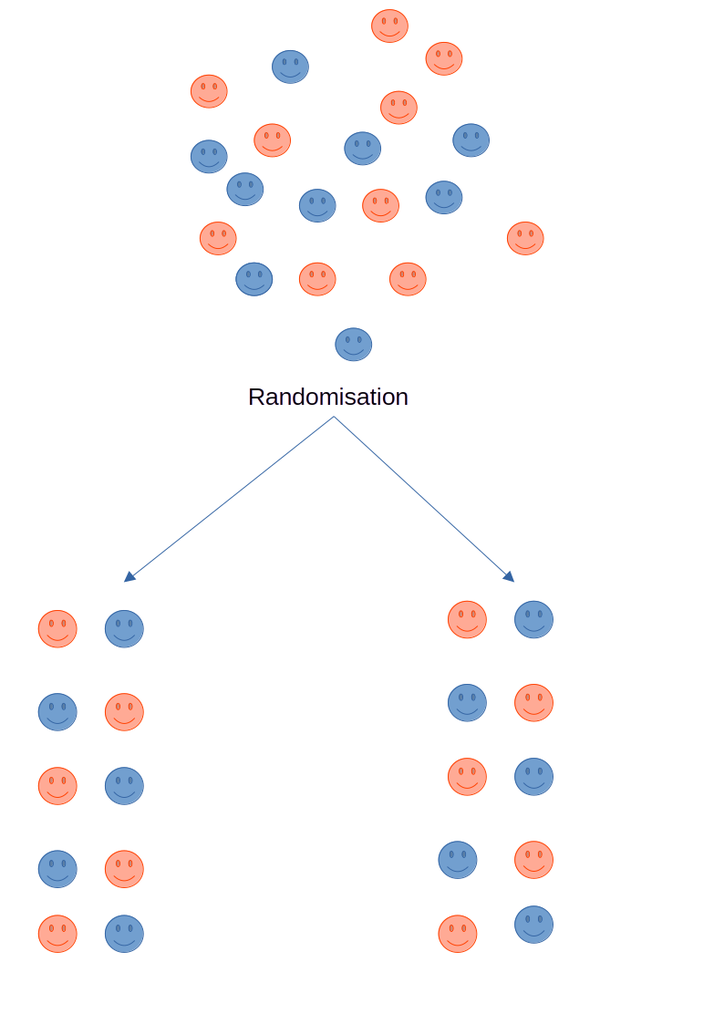

## What is Real world Data

- FDA definition “healthcare information derived from multiple sources outside of typical clinical research settings, including *electronic medical records (EMRs)*, *claims and billing data*, *product and disease registries*, and data gathered by *personal devices and health applications*”
- Offers a chance to identify and address gaps in clinical trial evidence

## Real World Data

- EMR (structured and unstructured clinical data reports, imaging, pathology, detailed treatment information)
- State-wide administrative datasets
  - Eg NSW Admitted Patient Data collection (Patient admission and discharge date, diagnostic codes, procedures), Emergency Department Data Collection
  - not designed for research
  - important clinical details (eg performance status, comorbidity, data on treatment including rational as well as key pathological features) are frequently poorly documented

## Real World Data (ctd)

- Cancer registries
  - Richer data sets
  - state-level registries only offer a core minimum dataset, have missing data, completeness of variables and timelines
  - multi-disciplinary,Multi-site national/international registries: more granular level data
- Linked data sets

## Limitations of Real World Data

1. Data availability and quality
2. Confounding due to no randomisation

## Observational data and the C-Word

” Dear author: Your observational study cannot prove causation. Please replace all references to causal effects by references to associations.”

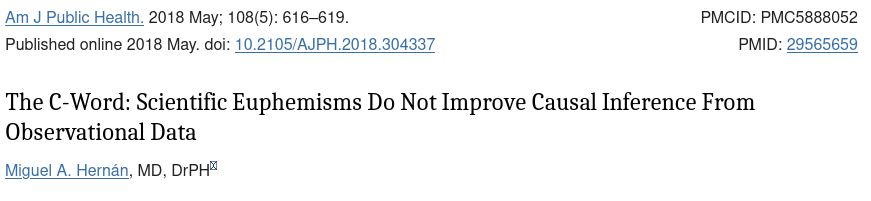

## The Target Trial framework

Plan analysis as though data are from a **hypothetical trial**:

- Eligibility criteria
- Time zero
- Treatment strategy clear definition
- Assignment procedure
- Follow-up period
- Outcome
- Causal contrast (eg ITT effect)
- Analysis plan

## Example

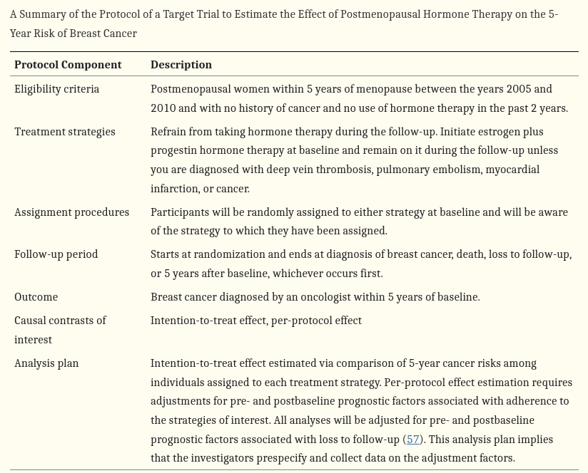

## Minimising the effect of confounders

- DAGs are useful tool for considering confounders
- “Draw your assumptions before your conclusions”
- forces the research team to carefully think through the confounding variables and their interrelationships

## Example DAG

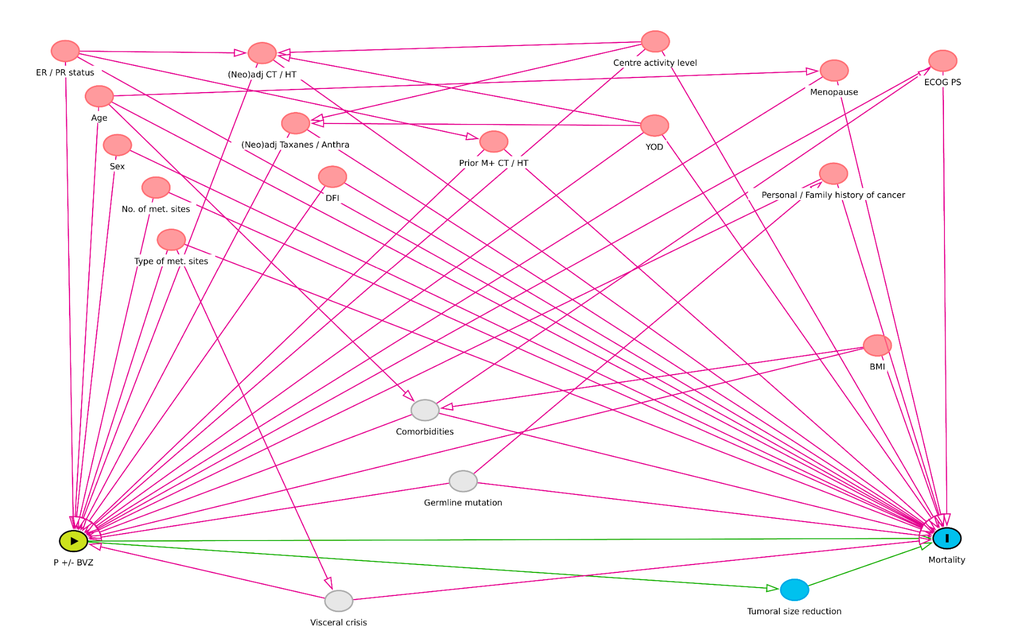

## Propensity Matching

- create a “matched population” where the treated and untreated are exchangeable (similar in all other characteristics)
- Propensity scores allow is to determine similarity
- Propensity score is prob of treatment conditional on confounders
- For each treated individual find a untreated individual with a similar propensity score

## How well did we achieve ballance

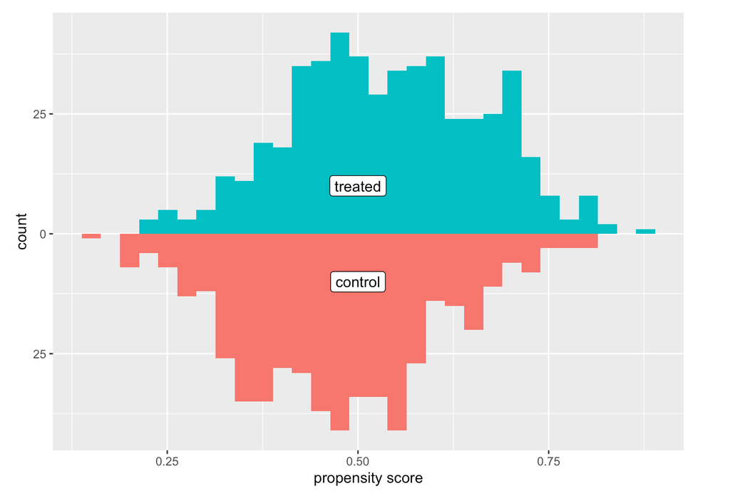

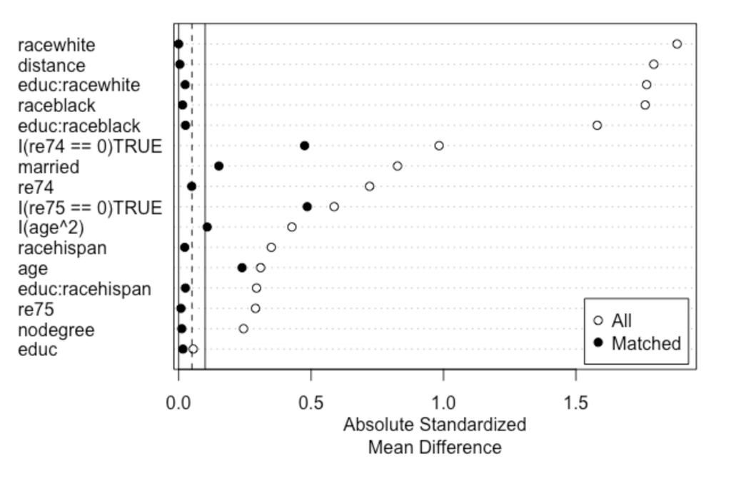

## What about umeasured confounders??

- Should perform a sensitivity analysis
- How robust are the results/conclusions to possible un-measured confounders
- The E-value - How big a relative risk (between exposure and confounder) would need be to nullify an effect
- If bigger than any of the measured ones then that means unlikely
- If small then casts doubt on the results

## Conclusions

- We can talk about causal effects from real world data
- There are many great local resources
- Should use the target trial framework
- More advanced methods for controlling confounders
- Need sensitivity analyses